# CourseProject

Jacek Glen

13 March 2016

## Introduction

Using devices such as Jawbone Up, Nike FuelBand, and Fitbit it is now possible to collect a large amount of data about personal activity relatively inexpensively. These type of devices are part of the quantified self movement – a group of enthusiasts who take measurements about themselves regularly to improve their health, to find patterns in their behavior, or because they are tech geeks. One thing that people regularly do is quantify how much of a particular activity they do, but they rarely quantify how well they do it. In this project, your goal will be to use data from accelerometers on the belt, forearm, arm, and dumbell of 6 participants. They were asked to perform barbell lifts correctly and incorrectly in 5 different ways. More information is available from the website here: [http://groupware.les.inf.puc-rio.br/har] (see the section on the Weight Lifting Exercise Dataset).

## Project Goals

The goal of this project is to predict the manner in which they did the exercise. This is the “classe” variable in the training set. You may use any of the other variables to predict with. You should create a report describing how you built your model, how you used cross validation, what you think the expected out of sample error is, and why you made the choices you did. You will also use your prediction model to predict 20 different test cases. Peer Review Portion

1. Your submission for the Peer Review portion should consist of a link to a Github repo with your R markdown and compiled HTML file describing your analysis. Please constrain the text of the writeup to < 2000 words and the number of figures to be less than 5. It will make it easier for the graders if you submit a repo with a gh-pages branch so the HTML page can be viewed online (and you always want to make it easy on graders :-). Course Project Prediction Quiz Portion
2. Apply your machine learning algorithm to the 20 test cases available in the test data above and submit your predictions in appropriate format to the Course Project Prediction Quiz for automated grading.

### Data

The training data for this project are available here:

[https://d396qusza40orc.cloudfront.net/predmachlearn/pml-training.csv]

The test data are available here:

[https://d396qusza40orc.cloudfront.net/predmachlearn/pml-testing.csv]

The data for this project come from this source: [http://groupware.les.inf.puc-rio.br/har]. If you use the document you create for this class for any purpose please cite them as they have been very generous in allowing their data to be used for this kind of assignment.

Data can be read into two data frames.

```r
pmlTrainRaw <- read.csv("pml-training.csv", na.strings=c("NA","#DIV/0!",""))
pmlTestRaw <- read.csv("pml-testing.csv", na.strings=c("NA","#DIV/0!",""))

dim(pmlTrainRaw)
```

```
## [1] 19622   160
```

```r
dim(pmlTestRaw)
```

```
## [1]  20 160
```

There are 19622 observations in the training set. Each observation has 158 variables plus id and “classe” columns. The latter is the outcome to predict. The test class contains 20 observations for which the outcome must be found. The last columnt “problem_id” is just for identification purposes.

## Libraries used in the project

Load required libraries

```r
library(caret)
library(rpart)
library(rpart.plot)
library(randomForest)
library(corrplot)
```

### Data clean-up

To clean up the data, firstly we remove variables with no real values (NA).

```r
pmlTrainRaw <- pmlTrainRaw[, colSums(is.na(pmlTrainRaw)) == 0]
pmlTestRaw <- pmlTestRaw[, colSums(is.na(pmlTestRaw)) == 0]
```

Secondly let’s remove variables not contributing to the final outcome (timestamps and control data)

```r
classeSave <- pmlTrainRaw$classe

trainRemove <- grepl("^X|timestamp|window", names(pmlTrainRaw))
pmlTrainRaw <- pmlTrainRaw[, !trainRemove]
pmlTrainClean <- pmlTrainRaw[, sapply(pmlTrainRaw, is.numeric)]
pmlTrainClean$classe <- classeSave

testRemove <- grepl("^X|timestamp|window", names(pmlTestRaw))
pmlTestRaw <- pmlTestRaw[, !testRemove]
pmlTestClean <- pmlTestRaw[, sapply(pmlTestRaw, is.numeric)]

dim(pmlTrainClean)
```

```
## [1] 19622    53
```

```r
dim(pmlTestClean)
```

```
## [1] 20 53
```

This has significantly reduced the number of variables.

### Slicing the data

Next, I withhold 25% of the dataset for testing after the final model is constructed.

```r
set.seed(654321) #for reproducibile purposes
inTrain <- createDataPartition(pmlTrainClean$classe, p=0.75, list=FALSE)
trainData <- pmlTrainClean[inTrain, ]
testData <- pmlTrainClean[-inTrain, ]
```

## Data Modeling

The model is fitted using **Random Forest** algorithm because it automatically selects important variables and is robust to correlated covariates & outliers in general. I use **out-of-bag estimates** for the random forest control.

```r
ctrlRF <- trainControl(method = "oob")
modelRF <- train(classe ~ ., data=trainData, method="rf", ntree = 200, trControl = ctrlRF)
modelRF
```

```
## Random Forest
##
## 14718 samples
##    52 predictor
##     5 classes: 'A', 'B', 'C', 'D', 'E'
##
## No pre-processing
## Resampling results across tuning parameters:
##
##   mtry  Accuracy   Kappa
##    2    0.9937492  0.9920923
##   27    0.9932735  0.9914911
##   52    0.9866150  0.9830678
##
## Accuracy was used to select the optimal model using  the largest value.
## The final value used for the model was mtry = 2.
```

Validate model performance using saved data set.

```r
resultRF <- predict(modelRF, testData)
confusionMatrix(testData$classe, resultRF)
```

```
## Confusion Matrix and Statistics
##
##           Reference
## Prediction    A    B    C    D    E
##          A 1395    0    0    0    0
##          B    2  947    0    0    0
##          C    0    7  848    0    0
##          D    0    0   15  789    0
##          E    0    0    0    2  899
##
## Overall Statistics
##
##                Accuracy : 0.9947
##                  95% CI : (0.9922, 0.9965)
##     No Information Rate : 0.2849
##     P-Value [Acc > NIR] : < 2.2e-16
##
##                   Kappa : 0.9933
##  Mcnemar's Test P-Value : NA
##
## Statistics by Class:
##
##                      Class: A Class: B Class: C Class: D Class: E
## Sensitivity            0.9986   0.9927   0.9826   0.9975   1.0000
## Specificity            1.0000   0.9995   0.9983   0.9964   0.9995
## Pos Pred Value         1.0000   0.9979   0.9918   0.9813   0.9978
## Neg Pred Value         0.9994   0.9982   0.9963   0.9995   1.0000
## Prevalence             0.2849   0.1945   0.1760   0.1613   0.1833
## Detection Rate         0.2845   0.1931   0.1729   0.1609   0.1833
## Detection Prevalence   0.2845   0.1935   0.1743   0.1639   0.1837
## Balanced Accuracy      0.9993   0.9961   0.9904   0.9969   0.9998
```

```r
postResample(resultRF, testData$classe)
```

```
##  Accuracy     Kappa
## 0.9946982 0.9932932
```

From the above we can see that the model estimated accuracy is 99.47% with out-of-sample error of 0.53%.

## Applying the prediction to the test data set

The last step is to apply the model on the original test data. Here I also remove the last column “problem_id” which is used for identification purposes only.

```r
predict(modelRF, pmlTestClean[, -length(names(pmlTestClean))])
```

```
##  [1] B A B A A E D B A A B C B A E E A B B B
## Levels: A B C D E
```

## Appendix: Figures

1. Correlation Matrix Visualization

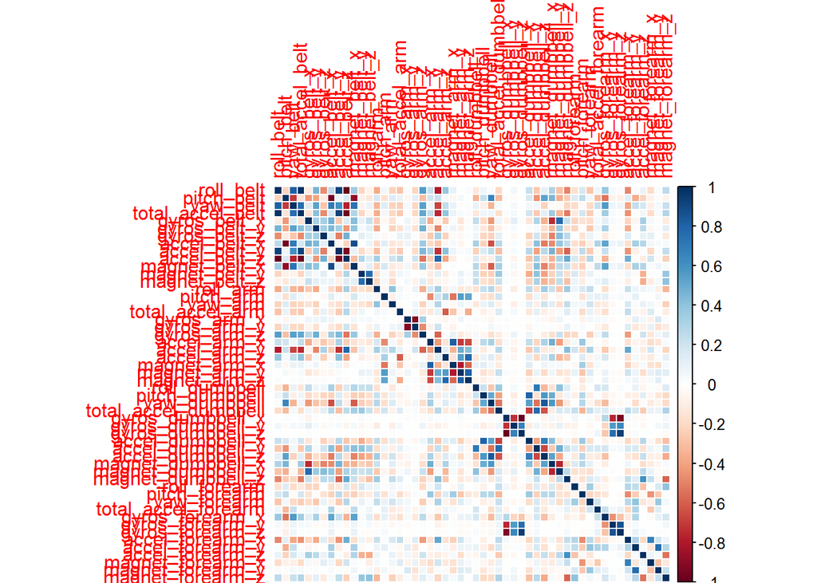

```r
corrplot(cor(trainData[, -length(names(trainData))]), method="color")
```

2. Decision Tree Visualization

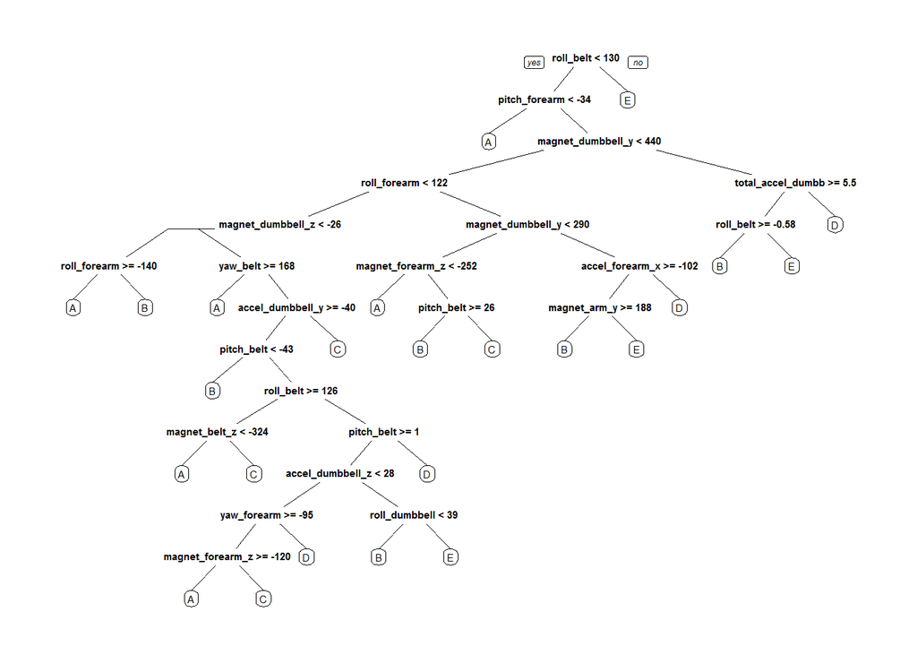

```r
prp(rpart(classe ~ ., data=trainData, method="class"))
```